# Exploratory Analysis

## Music Trends Throughout the Years

### Authors: June Hong (junehong@uw.edu), Deborah Kwon (dnkwon@uw.edu), Abigail Setiawan (tsetia@uw.edu), Paul Lam (paul0h@uw.edu)

### Date: 02/20/2023

### Abstract

Our main question is how do music trends reflect patterns in society? This question is important because the music people consume has a deep tie to their opinions and emotions, which can change when large events happen in the world. We are concerned with music trends and how they changed around major world events because it can reflect the mindset that people may have had at the time.

### Keywords

Music trends, user consumption, pop culture.

### Introduction

Music is an essential part of our lives. Whether we are studying, working out, hanging with friends, music is always there. The presence of music helps us when we are sad, motivates us when we’re lazy, and can calm us down. However, today’s popular music genres are not the same as when our grandparents were kids. When our grandparents were kids, they listened to rock n roll in the 1950’s. Nowadays, we listen to all sorts of music with R&B/hip-hop, Latin, rock, pop, and world music accounting for the top five most popular genres. What has influenced all these music changes throughout the years? What roles do political, sociological, and economical challenges play in the popular music genres throughout the years? When we are sad, we listen to soft music and when we are happy, we listen to upbeat music. Music choice is chosen based on one’s mood. Could emotions caused by daily life challenges be a player in the changes of popular music genres? It is important to track these trends because over the course of the past century, so much has changed and happened in our world. Tracking music trends can help us analyze what people were feeling at the time and take a peek into what life was like for each century.

### Related Work

This project will be looking at music trends throughout the years. Music trends can reflect broader events and patterns in society, such as the rise of social media, changing perceptions of the world, political unrest, economical changes, and great tragedies. Listening to music also has a deeply psychological effect, and can impact the listener’s mindset, mood, energy levels, stress levels, and memory. Christopher Rea’s study (2010) focused on the correlation between certain music genres and people’s mood, by recording participants’ moods before and after listening to music genres such as rock, classical, and pop. Stefan Hall’s article (2020) describes the effect of the Covid-19 pandemic on the music industry, such as the increase in broadcasted live performances, the changes in the global music industry’s revenue, and changes in advertising for newly released music. Kamran Ahmed’s article discusses the impact of historical events on the music industry (2022), such as the first ever music academy being built, the Romanticism cultural movement, and the Renaissance. Recording music trends is important because it can reflect broader themes than what meets the eye: oftentimes, changes in music’s genre and style often goes hand in hand with the mindsets of the people listening to the music. This can be caused by the changing world and sentiments as time progresses.

Citations:

Hall, S.B. (2020) This is how covid-19 is affecting the music industry, World Economic Forum. Available at: https://www.weforum.org/agenda/2020/05/this-is-how-covid-19-is-affecting-the-music-industry/ (Accessed: January 30, 2023).

Ahmed, K. (2022) Influence of historical events on music, Stage Music Center In Acton and Winchester MA. Stage Music Center In Acton and Winchester MA. Available at: https://stagemusiccenter.com/music-school-blog-winchester-acton-ma/2022/10/1/influence-of-historical-events-on-music (Accessed: January 31, 2023).

Rea, C. (2010) Listening to classical, pop, and metal music: An investigation of mood, Emporia State Research Studies. Available at: https://esirc.emporia.edu/bitstream/handle/123456789/381/205.1.pdf?sequence=1 (Accessed: January 31, 2023).

### The Dataset

Where did you find the data? Please include a link to the data source https://www.kaggle.com/datasets/musicblogger/spotify-music-data-to-identify-the-moods?resource=download

Who collected the data? Spotify

How was the data collected or generated? Not specified.

Why was the data collected? Not specified.

How many observations (rows) are in your data? 686

How many features (columns) are in the data? 19

What, if any, ethical questions or questions of power do you need to consider when working with this data? There are not any apparent questions of power or ethical questions to think about with our data.

What are possible limitations or problems with this data? (at least 200 words) In the case of the dataset that we chose, some characteristics in the form of numbers did not include a unit, which could be ambiguous to implicate since some characteristics have multiple units that could be applied, for example is the song length column. Another example is the key column which has numbers from 1-11 as indication of the key the song is played in, which is unclear what the numbers exactly represent in the music. For this reason, this data set could be hard to work with for people with no music knowledge as it does not include a code book or other forms of resources to provide detail on the columns. It is also unstated how and for what purpose the data was generated, so the legitimacy of the dataset is a subject to obscurity. Some of the dates inside the year category also do not have a specific date of release and only mentions the year it was released, which is inconsistent. Some columns in the dataset are also filled with “0” which could mean that those specific characters in the data are “0”, but it could also mean that some data are missing. Finally, the “mood” column in the data has a relatively narrow selection of moods, considering human’s complex emotions.

### Limitations & Challenges

Given that we’re looking at a long span of music reaching back to the 1900s to now, it’s hard to really address the intricacies of the entire range of music people consumed over the years. We’re definitely looking at things with a more broad, top level approach and some trends might be missed. This is something to keep in mind as we look at the data and consider the trends we look at. It’s also very possible that there could be confounding variables that we miss out on when looking at how music has changed over the years. Music and culture can be volatile when it comes to pinpointing reasons for trends. So in general, it’ll be important to keep an attention to detail, and take a look at all the different categories in our dataset, in order to make the most informed observations and analysis about the topic.

### Summary Information

Our three charts show many different aspects of how music can effect the human psyche. Our first chart shows how the mood of music changed throughout periods of time, especially surrounding major events such as recessions, political unrest, COVID-19, and the rapid growth of the internet. Our second chart shows how the average length of songs increase and decrease based on factors such as economic growth and stability. Our third chart shows the correlation between tempo and the mood of the listener, which poses the question of which comes first: the mood of the person or their music choice?

| X | year | name | album | artist | release_date | popularity | energy | valence | tempo | time_signature | mood |
| --- | --- | --- | --- | --- | --- | --- | --- | --- | --- | --- | --- |
| 1 | 2018 | lovely (with Khalid) | lovely (with Khalid) | Billie Eilish | 2018-04-19 | 88 | 0.296 | 0.1200 | 115.284 | 4 | Sad |
| 2 | 2019 | Falling | Fine Line | Harry Styles | 2019-12-13 | 87 | 0.267 | 0.0592 | 110.011 | 4 | Sad |
| 3 | 2019 | when the party’s over | WHEN WE ALL FALL ASLEEP, WHERE DO WE GO? | Billie Eilish | 2019-03-29 | 87 | 0.111 | 0.1980 | 82.642 | 4 | Sad |
| 4 | 2020 | you broke me first | you broke me first | Tate McRae | 2020-04-17 | 87 | 0.374 | 0.0799 | 124.099 | 4 | Sad |
| 5 | 2013 | All of Me | Love In The Future (Expanded Edition) | John Legend | 2013-08-30 | 85 | 0.264 | 0.3310 | 119.930 | 4 | Sad |
| 6 | 1982 | Africa | Toto IV | TOTO | 1982-04-08 | 84 | 0.373 | 0.7320 | 92.717 | 4 | Happy |
| 7 | 1985 | Take on Me | Hunting High and Low | a-ha | 1985-06-01 | 84 | 0.902 | 0.8760 | 84.412 | 4 | Happy |
| 8 | 2011 | Pumped Up Kicks | Torches | Foster The People | 2011-05-23 | 84 | 0.710 | 0.9650 | 127.975 | 4 | Happy |
| 9 | 1969 | Here Comes The Sun - Remastered 2009 | Abbey Road (Remastered) | The Beatles | 1969-09-26 | 83 | 0.540 | 0.3940 | 129.171 | 4 | Happy |
| 10 | 1979 | Highway to Hell | Highway to Hell | AC/DC | 1979-07-27 | 83 | 0.913 | 0.4230 | 115.728 | 4 | Happy |
| 11 | 1972 | Rocket Man (I Think It’s Going To Be A Long, Long Time) | Honky Chateau | Elton John | 1972-05-19 | 82 | 0.532 | 0.3410 | 136.571 | 4 | Happy |
| 12 | 1977 | Mr. Blue Sky | Out of the Blue | Electric Light Orchestra | 1977 | 82 | 0.338 | 0.4770 | 177.784 | 4 | Happy |
| 13 | 2001 | Chop Suey! | Toxicity | System Of A Down | 2001-09-04 | 79 | 0.934 | 0.2860 | 127.288 | 4 | Energetic |
| 14 | 2014 | Jealous | Jealous | Labrinth | 2014-11-21 | 79 | 0.155 | 0.0935 | 128.532 | 3 | Sad |
| 15 | 1992 | Killing In The Name | Rage Against The Machine - XX (20th Anniversary Special Edition) | Rage Against The Machine | 1992 | 78 | 0.833 | 0.6610 | 88.785 | 4 | Energetic |
| 16 | 2012 | Little Talks | My Head Is An Animal | Of Monsters and Men | 2012-01-01 | 78 | 0.757 | 0.4170 | 102.961 | 4 | Happy |
| 17 | 1973 | The Joker | The Joker | Steve Miller Band | 1973-01-01 | 77 | 0.448 | 0.7960 | 83.293 | 4 | Happy |
| 18 | 1981 | Start Me Up - Remastered | Tattoo You (2009 Re-Mastered) | The Rolling Stones | 1981-08-24 | 77 | 0.932 | 0.9710 | 122.429 | 4 | Happy |
| 19 | 1993 | Mr. Jones | August And Everything After | Counting Crows | 1993-01-01 | 77 | 0.817 | 0.7260 | 141.621 | 4 | Happy |
| 20 | 2006 | Crazy | St. Elsewhere | Gnarls Barkley | 2006-04-24 | 77 | 0.587 | 0.6400 | 111.970 | 4 | Happy |
| 21 | 2006 | Dani California | Stadium Arcadium | Red Hot Chili Peppers | 2006-05-09 | 77 | 0.913 | 0.7300 | 96.184 | 4 | Energetic |
| 22 | 2004 | Duality | Vol. 3: The Subliminal Verses | Slipknot | 2004 | 76 | 0.982 | 0.1940 | 143.772 | 4 | Energetic |
| 23 | 2017 | Easily | A Song For Every Moon | Bruno Major | 2017-08-31 | 76 | 0.256 | 0.3570 | 118.902 | 3 | Sad |
| 24 | 2003 | Are You Gonna Be My Girl | Get Born | Jet | 2003-09-15 | 75 | 0.953 | 0.5370 | 105.046 | 4 | Happy |
| 25 | 2009 | Uprising | The Resistance | Muse | 2009-09-10 | 75 | 0.905 | 0.4110 | 128.019 | 4 | Energetic |
| 26 | 1963 | Twist And Shout - Remastered 2009 | Please Please Me (Remastered) | The Beatles | 1963-03-22 | 74 | 0.849 | 0.9370 | 124.631 | 4 | Happy |
| 27 | 1967 | Happy Together | Happy Together | The Turtles | 1967 | 74 | 0.367 | 0.5880 | 120.175 | 4 | Happy |
| 28 | 1978 | Don’t Stop Me Now - 2011 Mix | Jazz (Deluxe Remastered Version) | Queen | 1978-11-10 | 74 | 0.865 | 0.6010 | 156.271 | 4 | Happy |
| 29 | 1986 | Kiss | Parade - Music from the Motion Picture Under the Cherry Moon | Prince | 1986-03-31 | 73 | 0.271 | 0.7420 | 111.485 | 4 | Happy |
| 30 | 1996 | Send Me on My Way | Music From Party of Five | Various Artists | 1996-11-12 | 73 | 0.681 | 0.7450 | 119.460 | 4 | Happy |
| 31 | 2000 | Papercut | Hybrid Theory (Bonus Edition) | Linkin Park | 2000-10-24 | 73 | 0.939 | 0.6610 | 150.184 | 4 | Energetic |
| 32 | 1991 | Two Princes | Pocket Full Of Kryptonite | Spin Doctors | 1991-08-27 | 72 | 0.912 | 0.8360 | 103.731 | 4 | Happy |
| 33 | 1999 | My Own Worst Enemy | A Place In The Sun | Lit | 1999-02-22 | 72 | 0.946 | 0.7410 | 103.408 | 4 | Energetic |
| 34 | 2005 | Better Together | In Between Dreams | Jack Johnson | 2005-01-01 | 72 | 0.347 | 0.6590 | 110.059 | 4 | Happy |
| 35 | 2007 | To Build A Home | Ma Fleur | The Cinematic Orchestra | 2007-05-07 | 72 | 0.122 | 0.0735 | 148.658 | 4 | Sad |
| 36 | 1976 | Night Moves | Night Moves | Bob Seger | 1976-10-22 | 71 | 0.743 | 0.3740 | 118.552 | 4 | Happy |
| 37 | 1980 | Video Killed The Radio Star | The Age Of Plastic | The Buggles | 1980-01-10 | 71 | 0.678 | 0.2510 | 131.165 | 4 | Happy |
| 38 | 1998 | Dragula | Hellbilly Deluxe | Rob Zombie | 1998-01-01 | 70 | 0.963 | 0.6090 | 125.030 | 4 | Energetic |
| 39 | 2008 | Savior | Appeal To Reason | Rise Against | 2008-01-01 | 70 | 0.931 | 0.4670 | 112.548 | 4 | Energetic |
| 40 | 1990 | What I Like About You | What I Like About You (And Other Romantic Hits) | The Romantics | 1990 | 68 | 0.915 | 0.9200 | 159.810 | 4 | Happy |
| 41 | 1994 | Lovely Day | Lean on Me: The Best of Bill Withers | Bill Withers | 1994-08-09 | 67 | 0.565 | 0.6920 | 97.937 | 4 | Happy |
| 42 | 2016 | No Woman | Light Upon the Lake | Whitney | 2016-06-03 | 66 | 0.400 | 0.4330 | 112.331 | 4 | Sad |
| 43 | 2015 | Should Have Known Better | Carrie & Lowell | Sufjan Stevens | 2015-03-31 | 65 | 0.172 | 0.2970 | 90.972 | 4 | Sad |
| 44 | 1984 | Let’s Go Crazy | Purple Rain | Prince | 1984-06-25 | 63 | 0.930 | 0.3760 | 195.815 | 4 | Happy |
| 45 | 2002 | Always | Back Into Your System | Saliva | 2002-11-12 | 63 | 0.906 | 0.3710 | 181.964 | 4 | Energetic |
| 46 | 1983 | Talking In Your Sleep | In Heat | The Romantics | 1983-02-14 | 61 | 0.967 | 0.9770 | 129.766 | 4 | Happy |
| 47 | 2010 | Stupify | The Sickness (10th Anniversary Edition) | Disturbed | 2010-03-12 | 61 | 0.939 | 0.4220 | 98.000 | 4 | Energetic |
| 48 | 1975 | Why Can’t We Be Friends? | Why Can’t We Be Friends? | War | 1975-01-01 | 58 | 0.714 | 0.9620 | 92.448 | 4 | Happy |
| 49 | 1987 | Dance Little Sister | Introducing The Hardline According To Terence Trent D’Arby | Terence Trent D’Arby | 1987-07-06 | 53 | 0.696 | 0.9300 | 115.397 | 4 | Happy |
| 50 | 1966 | California Dreamin’ | If You Can Believe Your Eyes And Ears | The Mamas & The Papas | 1966-03 | 50 | 0.667 | 0.5970 | 112.749 | 4 | Happy |
| 51 | 1995 | Wonderwall | (What’s the Story) Morning Glory? | Oasis | 1995-10-02 | 15 | 0.844 | 0.4590 | 174.452 | 4 | Happy |
| 52 | 1997 | Tubthumping | Tubthumper | Chumbawamba | 1997 | 0 | 0.881 | 0.6250 | 206.941 | 4 | Happy |

| X | year | name | album | artist | release_date | popularity | energy | valence | tempo | time_signature | mood |
| --- | --- | --- | --- | --- | --- | --- | --- | --- | --- | --- | --- |
| 1 | 2018 | lovely (with Khalid) | lovely (with Khalid) | Billie Eilish | 2018-04-19 | 88 | 0.296 | 0.1200 | 115.284 | 4 | Sad |
| 2 | 2019 | Falling | Fine Line | Harry Styles | 2019-12-13 | 87 | 0.267 | 0.0592 | 110.011 | 4 | Sad |
| 3 | 2019 | when the party’s over | WHEN WE ALL FALL ASLEEP, WHERE DO WE GO? | Billie Eilish | 2019-03-29 | 87 | 0.111 | 0.1980 | 82.642 | 4 | Sad |
| 4 | 2020 | you broke me first | you broke me first | Tate McRae | 2020-04-17 | 87 | 0.374 | 0.0799 | 124.099 | 4 | Sad |
| 5 | 2013 | All of Me | Love In The Future (Expanded Edition) | John Legend | 2013-08-30 | 85 | 0.264 | 0.3310 | 119.930 | 4 | Sad |
| 6 | 1982 | Africa | Toto IV | TOTO | 1982-04-08 | 84 | 0.373 | 0.7320 | 92.717 | 4 | Happy |

```r
library(tidyverse)
library(ggplot2)
```

### Chart 1

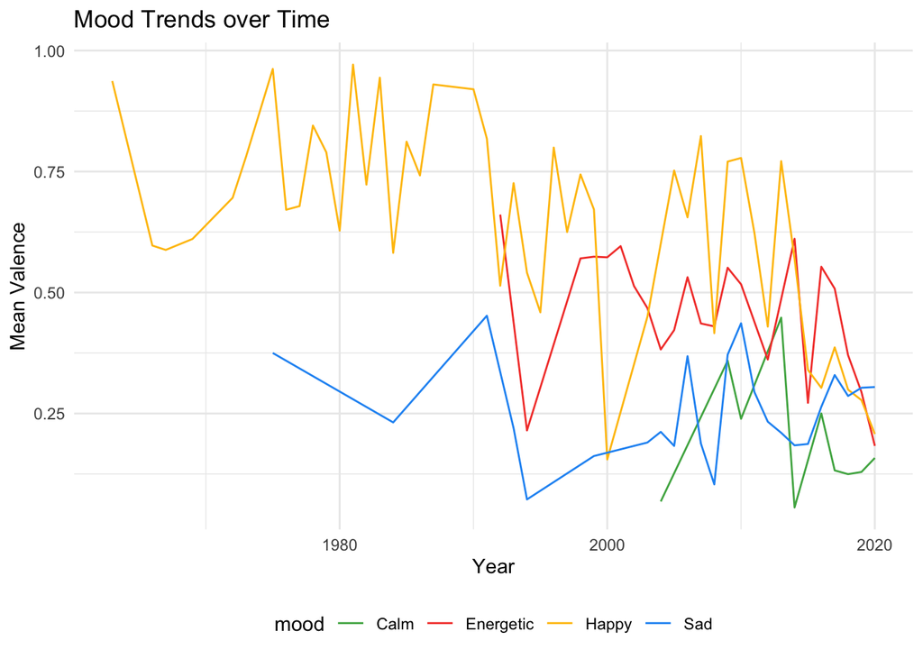

In our first chart, we can see that happy songs dominated from 1963 up until 2000. This is most likely because energetic and calm songs were not tracked at the time. However, when looking at sad and happy songs, the typical trend for when the valence of happy songs dropped was because of major events taking place both political and economical. Taking a look at the early 1990’s recession, the first few years of the recession resulted in an increase of sad songs and decrease of happy songs. Another example is from 2007 to 2008, happy music dropped when a recession first took place. We can also take a look at around 2019 and 2020 when COVID 19 happened, there was a drop in happy music and sad music dominated. This is due to many factors caused by the pandemic and many more issues. This resulted in an increase of mental health issues, economical issues, and sociological issues that ultimately brought down everyone’s mood which can be seen through the music being put out. Another case to look at was 1995 to 1999 where energetic music was soaring and happy music valence was high for the most part. This was the dot com era where many became rich and where massive growth of the internet happened. However, not soon after, the dot com bust which caused the stock market to crash in 2000, completely plummeting everyone’s mood hence the drastic drop in happy music.

### Chart 2

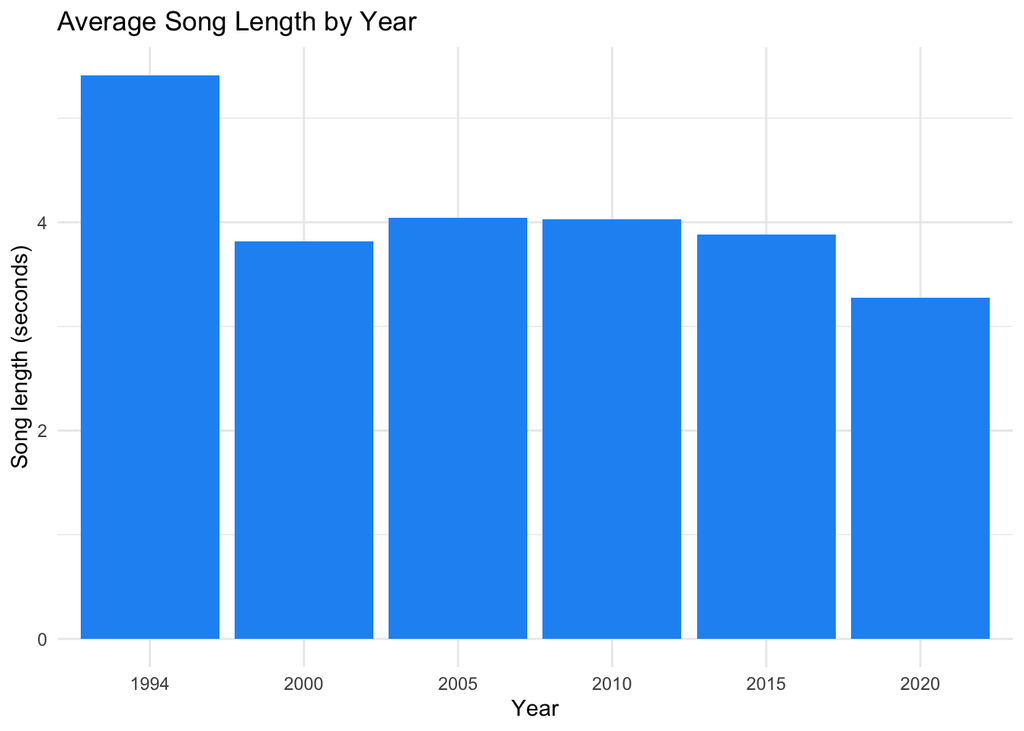

### Chart 3

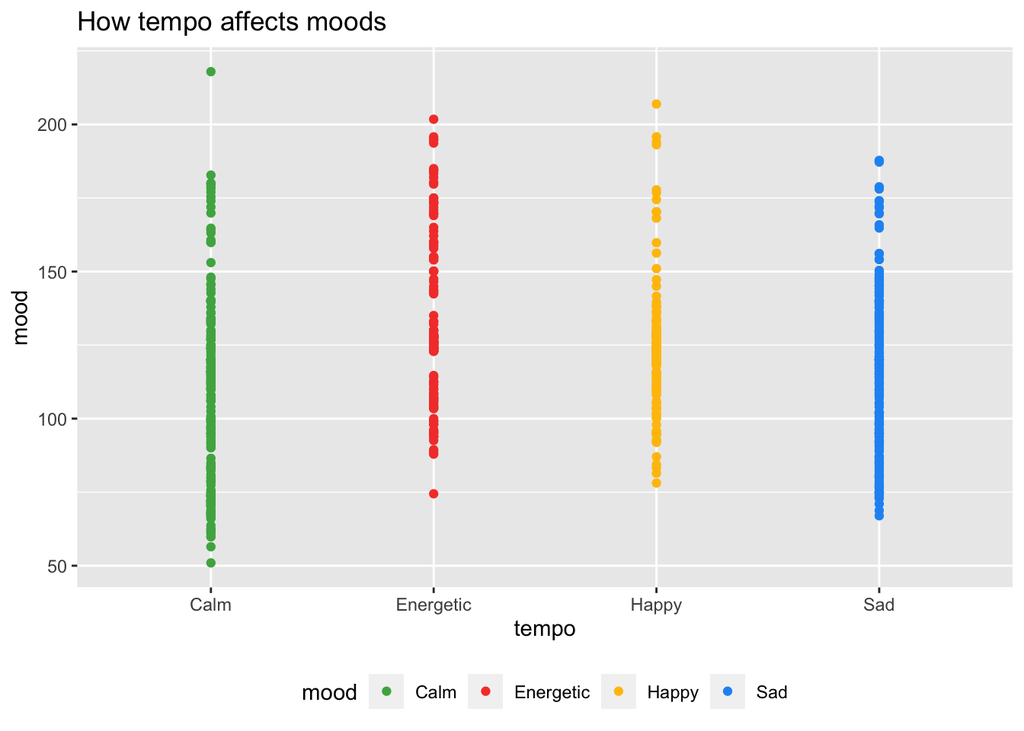

Link to exploratory analysis here: https://github.com/info-201a-wi23/exploratory-analysis-junemih